# EDA-challenge.Rmd

Sam Smith

2/7/2022

challenge posed over the weekend (2.5-2.6) Start by loading packages, data, and creating three new variables

```r
library(tidyverse)
```

```r
library(dplyr)
library(ggplot2)
# load in data
f <- "https://raw.githubusercontent.com/difiore/ada-2022-datasets/main/data-wrangling.csv"
d <- read_csv(f, col_names = TRUE) # creates a "tibble"
str(d) # what is the structure of the data
```

```
## spec_tbl_df [213 × 23] (S3: spec_tbl_df/tbl_df/tbl/data.frame)
##  $ Scientific_Name        : chr [1:213] "Allenopithecus_nigroviridis" "Allocebus_trichotis" "Alouatta_belzebul" "Alouatta_caraya" ...
##  $ Family                 : chr [1:213] "Cercopithecidae" "Cercopithecidae" "Atelidae" "Atelidae" ...
##  $ Genus                  : chr [1:213] "Allenopithecus" "Allocebus" "Alouatta" "Alouatta" ...
##  $ Species                : chr [1:213] "nigroviridis" "trichotis" "belzebul" "caraya" ...
##  $ Brain_Size_Species_Mean: num [1:213] 58 NA 52.8 52.6 51.7 ...
##  $ Body_mass_male_mean    : num [1:213] 6130 92 7270 6525 5800 ...
##  $ Body_mass_female_mean  : num [1:213] 3180 84 5520 4240 4550 5350 6430 5210 1230 NA ...
##  $ MeanGroupSize          : num [1:213] NA 1 7 8 6.53 12 6.6 7.1 3.1 3 ...
##  $ AdultMales             : num [1:213] NA 1 1 2.3 1.37 ...
##  $ AdultFemale            : num [1:213] NA 1 1 3.3 2.2 ...
##  $ GR_MidRangeLat_dd      : num [1:213] -0.17 -16.59 -6.8 -20.34 -21.13 ...
##  $ Precip_Mean_mm         : num [1:213] 1574 1902 1644 1166 1332 ...
##  $ Temp_Mean_degC         : num [1:213] 25.2 20.3 24.9 22.9 19.6 23.7 25.1 25.1 24.6 NA ...
##  $ HomeRange_km2          : num [1:213] NA NA NA NA 0.03 0.19 0.3 0.1 0.095 NA ...
##  $ DayLength_km           : num [1:213] NA NA NA 0.4 NA 0.32 NA 0.55 NA NA ...
##  $ Fruit                  : num [1:213] NA NA 57.3 23.8 5.2 33.1 40.8 40 45 NA ...
##  $ Leaves                 : chr [1:213] NA NA "19.1" "67.7" ...
##  $ Fauna                  : chr [1:213] NA NA "0" "0" ...
##  $ Canine_Dimorphism      : num [1:213] 2.21 NA 1.81 1.54 1.78 ...
##  $ Feed                   : num [1:213] NA NA 13.8 15.9 18.3 ...
##  $ Move                   : num [1:213] NA NA 18.8 17.6 14.3 ...
##  $ Rest                   : num [1:213] NA NA 57.3 61.6 64.4 ...
##  $ Social                 : num [1:213] NA NA 10 4.9 3 3.64 3.8 2.5 NA NA ...
##  - attr(*, "spec")=
##   .. cols(
##   ..   Scientific_Name = col_character(),
##   ..   Family = col_character(),
##   ..   Genus = col_character(),
##   ..   Species = col_character(),
##   ..   Brain_Size_Species_Mean = col_double(),
##   ..   Body_mass_male_mean = col_double(),
##   ..   Body_mass_female_mean = col_double(),
##   ..   MeanGroupSize = col_double(),
##   ..   AdultMales = col_double(),
##   ..   AdultFemale = col_double(),
##   ..   GR_MidRangeLat_dd = col_double(),
##   ..   Precip_Mean_mm = col_double(),
##   ..   Temp_Mean_degC = col_double(),
##   ..   HomeRange_km2 = col_double(),
##   ..   DayLength_km = col_double(),
##   ..   Fruit = col_double(),
##   ..   Leaves = col_character(),
##   ..   Fauna = col_character(),
##   ..   Canine_Dimorphism = col_double(),
##   ..   Feed = col_double(),
##   ..   Move = col_double(),
##   ..   Rest = col_double(),
##   ..   Social = col_double()
##   .. )
##  - attr(*, "problems")=<externalptr>
```

```r
names(d) # what are the variable names
```

```
##  [1] "Scientific_Name"         "Family"
##  [3] "Genus"                   "Species"
##  [5] "Brain_Size_Species_Mean" "Body_mass_male_mean"
##  [7] "Body_mass_female_mean"   "MeanGroupSize"
##  [9] "AdultMales"              "AdultFemale"
## [11] "GR_MidRangeLat_dd"       "Precip_Mean_mm"
## [13] "Temp_Mean_degC"          "HomeRange_km2"
## [15] "DayLength_km"            "Fruit"
## [17] "Leaves"                  "Fauna"
## [19] "Canine_Dimorphism"       "Feed"
## [21] "Move"                    "Rest"
## [23] "Social"
```

```r
# create body size dimorphism variable (BSD) (male:female body mass)
d = mutate(d, "BSD" = Body_mass_male_mean/Body_mass_female_mean,
           # sex ratio variable = # adult females : # adult males
           "sex_ratio" = AdultFemale/AdultMales,
           # defensibility index = day range length : diameter home range
           # note: HomeRange_km2 is area of homerange - calculated diameter assuming home range is a circle
           "DI" = DayLength_km/(2*sqrt(HomeRange_km2/pi)))
```

Plot the relationship between day range length and time spent moving, for these primate species overall and by family. Do species that spend more time moving travel farther overall? How about within any particular primate family? Should you transform either of these variables?

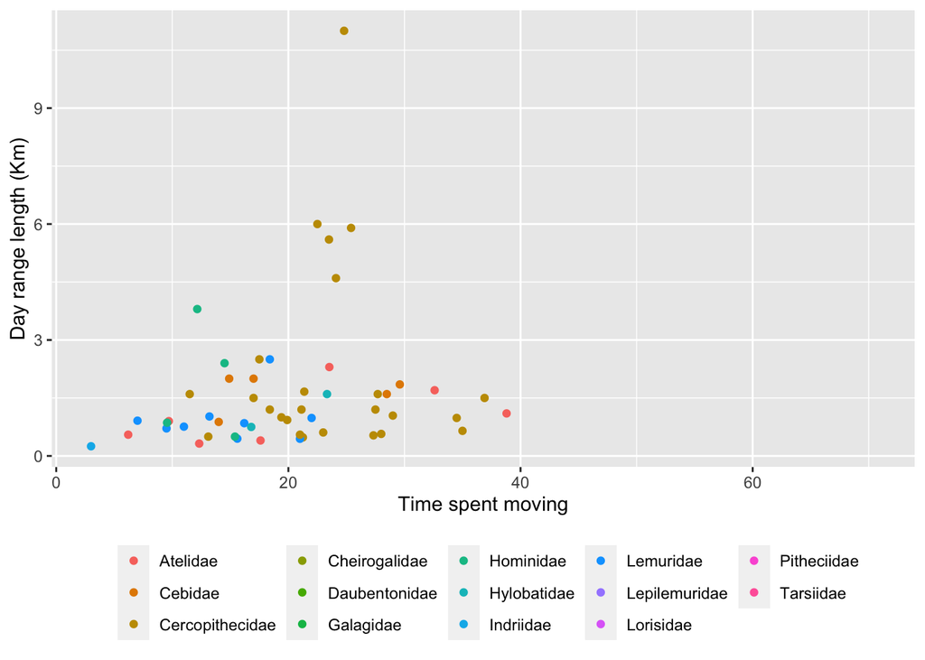

```r
# data plotted overall
ggplot(data=d,aes(x=Move,y=DayLength_km,color=factor(Family))) +
  xlab("Time spent moving") + ylab("Day range length (Km)") +
  geom_point(na.rm=TRUE) +
  theme(legend.position="bottom", legend.title=element_blank())
```

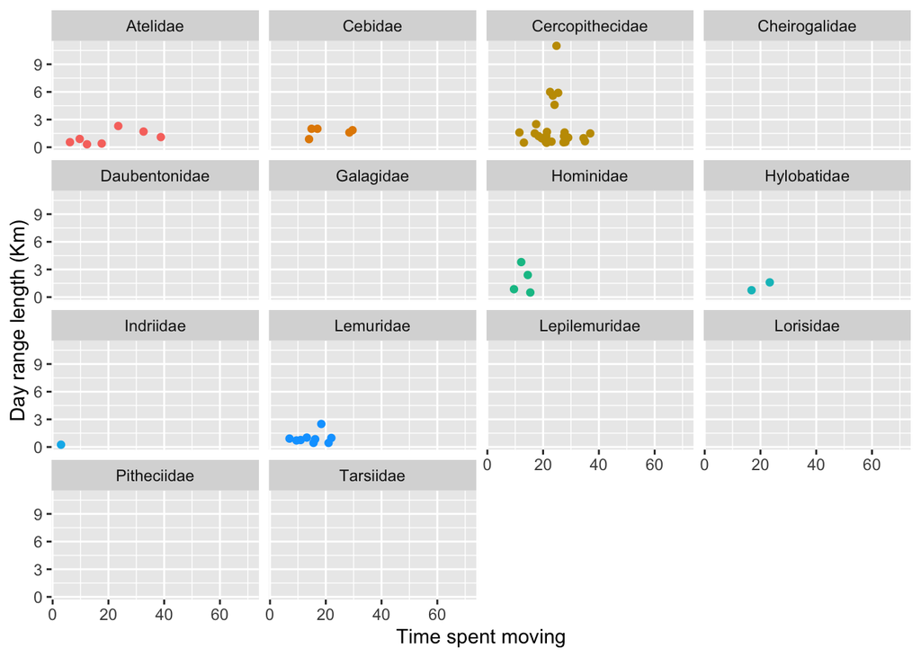

```r
# data plotted by family
ggplot(data=d,aes(x=Move,y=DayLength_km,color=factor(Family))) +
  xlab("Time spent moving") + ylab("Day range length (Km)") +
  geom_point(na.rm=TRUE) +
  facet_wrap(~ Family, ncol=4) +
  theme(legend.position="none")
```

Do species that spend more time moving travel farther overall? - umm not super clear relationship no. How about within any particular primate family? - looks like most don’t have a huge day range length except some Cercopithecidae.

Should you transform either of these variables?

Plot the relationship between day range length and group size, overall and by family. Do species that live in larger groups travel farther overall? How about within any particular primate family? Should you transform either of these variables?

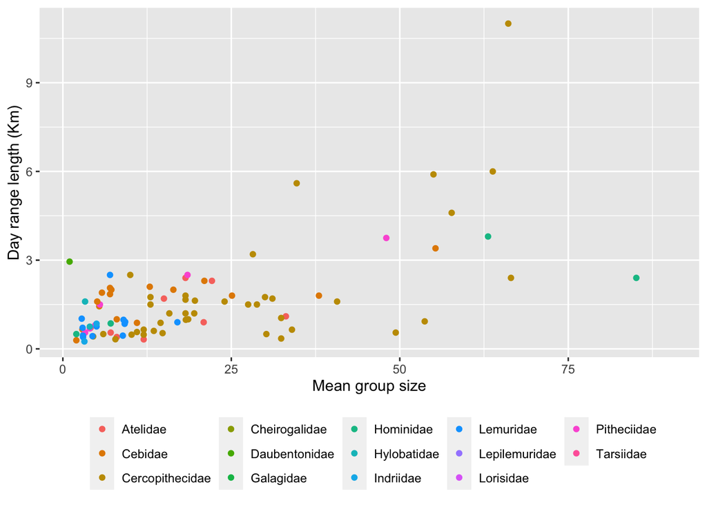

```r
# plotted overall
ggplot(data=d,aes(x=MeanGroupSize,y=DayLength_km,color=factor(Family))) +
  xlab("Mean group size") + ylab("Day range length (Km)") +
  geom_point(na.rm=TRUE) +
  theme(legend.position="bottom", legend.title=element_blank())
```

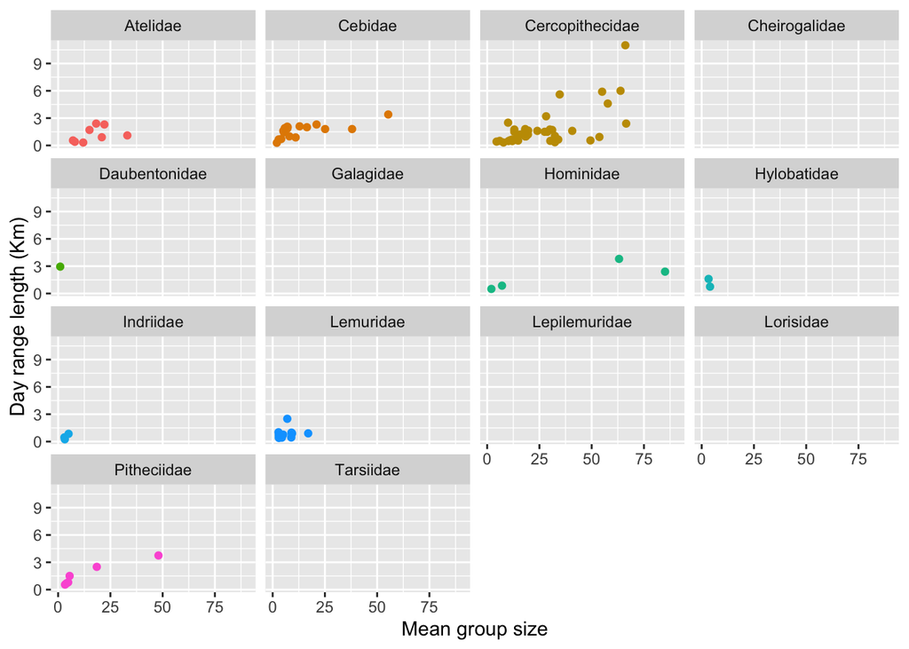

```r
# data plotted by family
ggplot(data=d,aes(x=MeanGroupSize,y=DayLength_km,color=factor(Family))) +
  xlab("Mean group size") + ylab("Day range length (Km)") +
  geom_point(na.rm=TRUE) +
  facet_wrap(~ Family, ncol=4) +
  theme(legend.position="none")
```

Seems like there might be a relationship…

Plot the relationship between body size dimorphism and canine size dimorphism overall and by family. Do taxa with greater size dimorphism also show greater canine dimorphism?

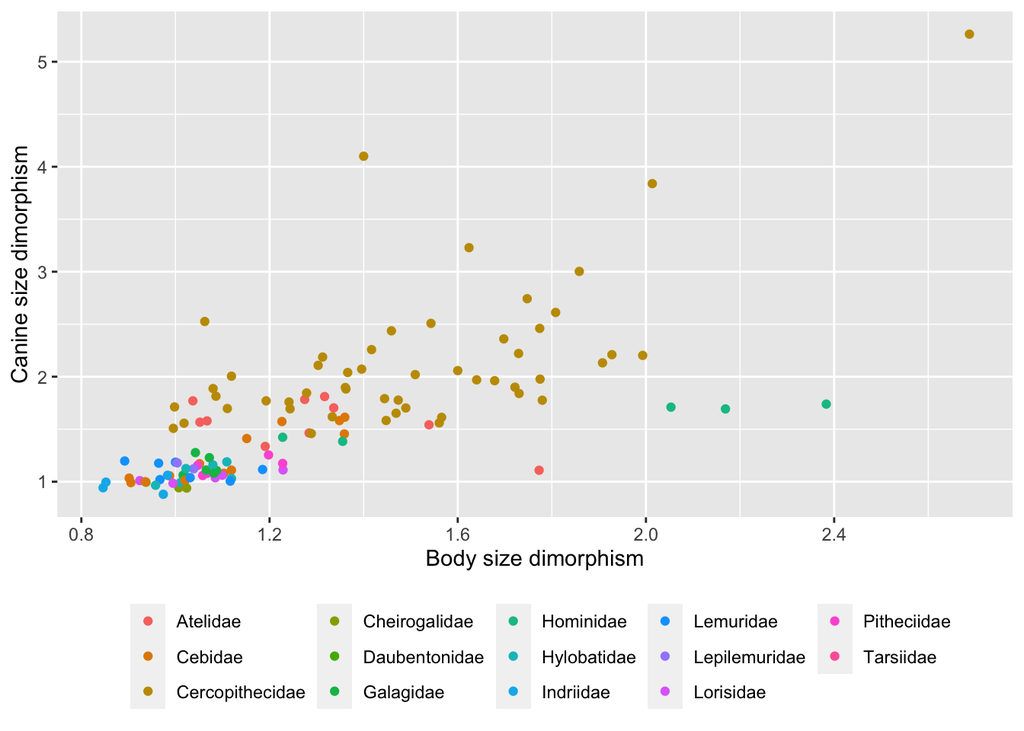

```r
# plotted overall
ggplot(data=d,aes(x=BSD,y=Canine_Dimorphism,color=factor(Family))) +
  xlab("Body size dimorphism") + ylab("Canine size dimorphism") +
  geom_point(na.rm=TRUE) +
  theme(legend.position="bottom", legend.title=element_blank())
```

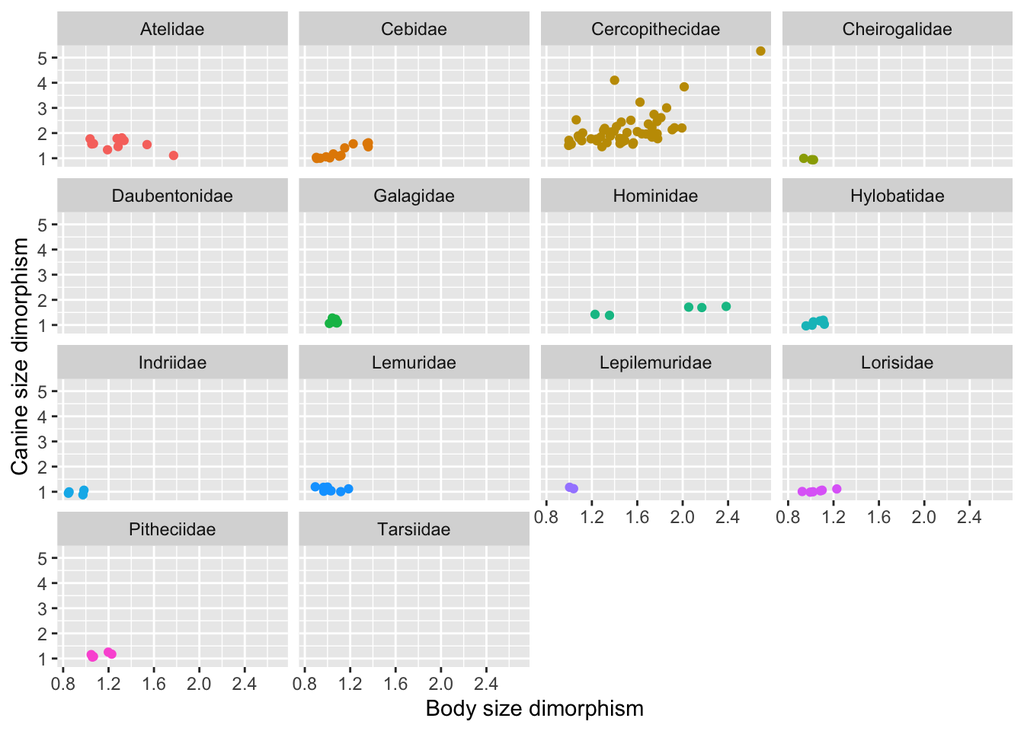

```r
# data plotted by family
ggplot(data=d,aes(x=BSD,y=Canine_Dimorphism,color=factor(Family))) +
  xlab("Body size dimorphism") + ylab("Canine size dimorphism") +
  geom_point(na.rm=TRUE) +
  facet_wrap(~ Family, ncol=4) +
  theme(legend.position="none")
```

```r
# using dplyr
d <- mutate(d, "diet_strategy" = case_when(Fruit >= 50 ~ "frugivore",
                             Leaves >= 50 ~ "folivore",
                             Fruit < 50 & Leaves < 50 ~ "omnivore"))
```

In one line of code, using dplyr verbs and the forward pipe (%>%) operator, do the following: Add a variable, Binomial to the data frame d, which is a concatenation of the Genus and Species… Trim the data frame to only include the variables Binomial, Family, Brain_size_species_mean, and Body_mass_male_mean… Group these variables by Family… Calculate the average value for Brain_size_species_mean and Body_mass_male_mean per Family (remember, you may need to specify na.rm = TRUE)… And arrange by increasing average brain size

```r
# add new variable
new_df <- mutate(d,"Binomial" = paste(Genus,Species,sep=" ")) %>%
  # select only a few columns
  select(Binomial, Family, Brain_Size_Species_Mean, Body_mass_male_mean) %>%
  # group data by family
  group_by(Family) %>%
  # find average brain size and average male mass for each fam
  summarize(avg_brain_size = mean(Brain_Size_Species_Mean, na.rm=TRUE),
          avg_mass_male = mean(Body_mass_male_mean, na.rm=TRUE)) %>%
  # arrange the data by increasing brain size
  arrange(avg_brain_size,decreasing=FALSE)

head(new_df)
```

```
## # A tibble: 6 × 3
##   Family        avg_brain_size avg_mass_male
##   <chr>                  <dbl>         <dbl>
## 1 Tarsiidae               3.26          131
## 2 Cheirogalidae           4.04          193.
## 3 Galagidae               5.96          395.
## 4 Lepilemuridae           7.27          792
## 5 Lorisidae               8.67          512.
## 6 Lemuridae              23.1          2077.
```